# MYO-II / Paper A — Which parts of the ENMO intensity spectrum carry longitudinal change?

Veronika Balounová

Compiled on: **2026-10-13** Last updated **2026-10-14

# 1 Executive summary

**Pre-specified localisation verdict (E3, invariance-checked):**

- **M18:** no evidence of a localised departure; smooth redistribution towards higher intensities
- **M3:** no evidence of a localised departure; smooth redistribution towards higher intensities
- **M6:** no evidence of a localised departure; smooth redistribution towards higher intensities

Where does change lie? Simultaneous 95% confidence sets for {change > 0}

| Estimand | Visit | Inner set (certainly > 0) | Outer set (plausibly > 0) |
| --- | --- | --- | --- |
| E1 bins | M3 | 90-300; 325-400 | 20-400 |
| E1 bins | M6 | 80-240 | 20-400 |
| E1 bins | M18 | 120-260 | 20-400 |
| E1 cumulative | M3 | T30-T375 | T20-T400 |
| E1 cumulative | M6 | T20-T200 | T20-T400 |
| E1 cumulative | M18 | T70-T280 | T20-T400 |
| E2 bins | M3 | 90-400 | 20->=400 |
| E2 bins | M6 | 80-240; 375-400 | 20->=400 |
| E2 bins | M18 | 140-260 | 20->=400 |
| E2 cumulative | M3 | T30-T350 | T20-T400 |
| E2 cumulative | M6 | T20-T220 | T20-T400 |
| E2 cumulative | M18 | T70-T325 | T20-T400 |

**Caution:** The simultaneous bands behind these sets are not separately calibrated per bin. The true-null simulation calibrates the ≥2-bin bump rule only. Treat the M18 sets (n = 39) with particular caution.

## Key messages for the clinical reader

These messages describe the full run of 2026-10-14 (B = 2000; the master md5 is in the reproducibility appendix). - Estimates, CIs, ranges and percentages are computed from the saved results when the report is knitted. - The qualitative wording was checked against that run. If the analysis is re-run on a different input, re-check that the wording still matches the numbers.

1. **Patients become clearly more active, and the gain is still present at M18.**
   - Time above 100 mg rose by 20.9 (95% CI 11.6 to 31.0) min/day at M3 and by 21.0 (95% CI 11.5 to 31.0) min/day at M6.
   - It was still 16.8 (95% CI 6.8 to 26.5) min/day higher at M18. This M18 estimate assumes missing-at-random, and dropout to M18 is informative (see the tipping-point analysis).
   - The baseline median was 51 min/day, so these are relative increases of +35 %, +36 % and +28 %.
2. **No evidence of a specific intensity band carrying the change.** The daily intensity distribution tilts smoothly towards higher accelerations:
   - the share of the day spent below 20 mg falls;
   - low-intensity bins (below ~100 mg) lose relative share;
   - higher-intensity bins gain relative share, the more so the higher the intensity.

   The pre-specified shape test found no localised departure at any visit, and the result was unchanged in every invariance check.

   What the test can and cannot see (true-null simulation, 500 datasets x 1000 bootstrap replicates per scenario and visit):
   - False alarms under a true null are rare: M3 2.0% (MC 95% CI 1-4%); M6 0.6% (MC 95% CI 0-2%); M18 0.8% (MC 95% CI 0-2%).
   - A localised extra gain of about +22% would very likely have been detected, whether narrow or broad: 97–100 % for 2 bins at 120–160 mg and 100 % for 6 bins at 70–140 mg.
   - A smaller extra gain (+10%) could have been missed, especially at M18: detection was 35–77 % for 2 bins and 49–76 % for 6 bins, and small broad departures may be flagged in the wrong place (mislocalised).
3. **Where minutes are gained and where the relative change is largest are different places.**
   - *Absolute* gain is certainly positive from about 80–90 mg upwards and is largest, in minutes, up to ~140 mg, where most active time is spent.
   - Similar point estimates below 80 mg are too imprecise to be distinguished from zero.
   - The *relative* increase is largest at high intensities: for example ×2.14 at 300–325 mg at M3. In absolute terms these are fractions of a minute per day.
4. **Early and later follow-up may differ (hypothesis).**
   - At M3 the relative gain at the highest intensities is largest: ×2.20 at 375–400 mg. It is smaller at M6 and M18 (×1.68 and ×1.49).
   - This is compatible with an early “burst” of more vigorous movement that settles into a mid-range increase.
   - It is a hypothesis, for three reasons:
     - the formal M3-vs-M6 comparison is not significant after multiplicity control;
     - M3 and M6 overlap in timing (2–6 vs 4–9 months);
     - the visits differ in season contrast (no M0→M6 pair falls in the same season).
5. **Response is heterogeneous.**
   - Between 51–83 % of patients gain time in a given bin from 70 mg upwards; in the lowest bins it is about half or fewer.
   - Above 200 mg, the 10% of patients with the largest gains contribute 46–75 % of the total gain.
6. **Subtypes (descriptive; pre-specified summaries).**
   - Change in time above 100 mg by subtype is shown in the subtype table and in F7.
   - Profiles differ in size between DM, IMNM and ASyS, but with 12–18 pairs per subtype and visit and no adjustment for severity, disease duration or treatment, no subtype conclusion is possible.
   - A properly powered subtype analysis is a next research question.
7. **Practical consequence.**
   - The data **do not support a new IIM-specific intensity cut-point**.
   - Time above a conventional threshold (e.g. 100 mg) and mean ENMO describe the volume of change.
   - The intensity gradient (IG) is a closely related, cut-point-free summary of the tilt. It tracks the patient-level tilt only moderately (ρ ≈ 0.69 at M6), and its group-level time course differs, so it is a reasonable but not equivalent summary.

**How to read this report.**

- Three questions are answered separately, each by its own pre-specified estimand:
  - **E1:** where time is gained, in absolute minutes/day per 10 mg;
  - **E2:** where the relative increase is largest, as a ratio of means;
  - **E3:** whether the *shape* of the intensity distribution changes beyond a smooth shift.
- Only E3 can support a claim of a specific informative interval.
- The location of a maximum depends on the estimand, so maxima are not presented as cut-points.

# 2 Research questions and estimands

| Code | Question | Estimand | Analysis set |
| --- | --- | --- | --- |
| E1 | Where in the spectrum is time gained? | Δ mean min/day per 10 mg, Mx − M0 (MMRM, unstructured covariance) | all measurements (MAR) |
| E2 | Where is the relative change largest? | ratio of marginal means Mx/M0 from the same MMRM | all measurements (MAR) |
| E3 | Does the shape change beyond a smooth shift? | mean paired clr change of a 21-part 24-h composition; residual from a natural-spline null in log intensity | complete pairs |
| E4 | Is change large relative to its variability? | dz = mean Δ / SD(Δ) | complete pairs |
| CUM | Complementary overlapping representation | E1/E2 for 24 cumulative thresholds | all measurements |

Estimable with these data:

- group-level change (E1/E2);
- precision of the group-level change (bootstrap SE);
- exposure prevalence (coverage).

**Not estimable** from the master dataset:

- individual test-retest reliability (ICC/SEM/SDC). This needs GGIR day-level output (`part2_daysummary`);
- clinical predictive value, which is out of scope.

# 3 Data source, cohort, QC and missingness

Cohort flow

| step | n |
| --- | --- |
| Records in master | 251 |
| QC-eligible records | 251 |
| Main-visit records (M0-M18) | 217 |
| Patients in main analysis | 71 |
| Exploratory records (M30-M60) | 34 |

**What it shows.** How many recordings and patients enter the analysis.

- All recordings passed device QC, including calibration error below 0.01 g.
- The main analysis uses the visits M0–M18. M30–M60 are shown only descriptively because they include few patients.

Data-integrity checks on the master dataset (PASS / WARN / FAIL / INFO)

| ID | Check | Status | Detail |
| --- | --- | --- | --- |
| D1 | Unique patient x visit (record_level) | PASS | 251 records |
| D2 | QC eligibility | PASS | 0 of 251 not eligible |
| D3 | Main sample (M0-M18) | INFO | 217 recordings / 71 patients; M0=63, M3=52, M6=57, M18=45 |
| D4 | Complete pairs with M0 | INFO | M3=47, M6=52, M18=39 |
| D5 | Patients without M0 | WARN | 8 patients (enter LMM, not paired analyses) |
| D6 | Threshold grid complete | PASS | 20,30,40,50,60,70,80,90,100,110,120,140,160,180,200,220,240,260,280,300,325,350,375,400 |
| D7 | Exclusive bins | PASS | 23 bounded bins 20-400 mg; open >400 bin present: FALSE |
| D8 | Cumulative monotonicity | PASS | 0 violations |
| D9 | bin = T_lo - T_hi | PASS | max &#124;error&#124; = 0.00e+00 |
| D10 | sum(bins) = T20 - T400 | PASS | max &#124;error&#124; = 0.00e+00 |
| D11 | minutes_per_10mg consistent | PASS | max &#124;error&#124; = 2.84e-14 |
| D12 | Non-negative bins | PASS | 0 negative |
| D13 | Exact zeros vs near-zero in bins | INFO | max exact-zero share 6.5%; bins with >50% <=1 min/day: 260,280,300,325,350,375 |
| D14 | Valid days (main sample) | WARN | 3d=1, 4d=6, 5d=13, 6d=172, 7d=25 |
| D15 | Month/season from start_time | PASS | season/month taken from local start_time (acc_date is shifted by 1 day in some records; not used) |
| D16 | Subtype coding | WARN | undefined codes (excluded from subtype analyses): NA |
| D18 | Months from M0: median (range) | WARN | M3 3.2 (2.0-6.0); M6 6.6 (4.3-9.4); M18 19.5 (16.5-21.8) |
| D19 | Season x visit | INFO | M0:Winter:6; M0:Spring:25; M0:Summer:14; M0:Autumn:18; M18:Winter:11; M18:Spring:14; M18:Summer:10; M18:Autumn:10; M3:Winter:10; M3:Spring:9; M3:Summer:15; M3:Autumn:18; M6:Winter:16; M6:Spring:15; M6… |

**How to read.**

- Every row is an automatic consistency check on the master dataset.
- **PASS** means the data obey the expected arithmetic. For example, time in an exclusive bin equals the difference of the two neighbouring cumulative thresholds, and time above a higher threshold is never larger than time above a lower one.
- **WARN** marks features that do not invalidate the data but must be considered in interpretation: patients without baseline, recordings with fewer than 5 valid days, overlapping M3/M6 timing windows, and undefined subtype codes.

**Evaluation.** There are no FAIL results, so the data are internally consistent and the derived exclusive bins are exact.

**Clinically relevant WARN: visit timing.**

- M3 was recorded 2–6 months after M0 and M6 4–9 months after M0, so the two windows partly overlap.
- “M3 vs M6” differences should therefore be read as *early vs later follow-up*, not as exact 3- and 6-month time points.
- A sensitivity analysis using the actual time since baseline gave the same picture.

Observed visit patterns (main visits)

| Visit pattern | Patients |
| --- | --- |
| M0-M3-M6-M18 | 34 |
| M0-M3-M6 | 11 |
| M0 | 8 |
| M0-M6-M18 | 4 |
| M0-M6 | 3 |
| M3-M6-M18 | 3 |
| M0-M3 | 2 |
| M18 | 2 |
| M0-M18 | 1 |
| M3 | 1 |
| M3-M6 | 1 |
| M6-M18 | 1 |

**What it shows.** Which visits each patient contributed. Only about half of the patients have all four main visits.

**Why it matters.** The mixed model (MMRM) uses every available measurement and remains valid when missingness depends on what was already observed (MAR). The simpler paired comparisons (M0 vs Mx) use only patients with both visits.

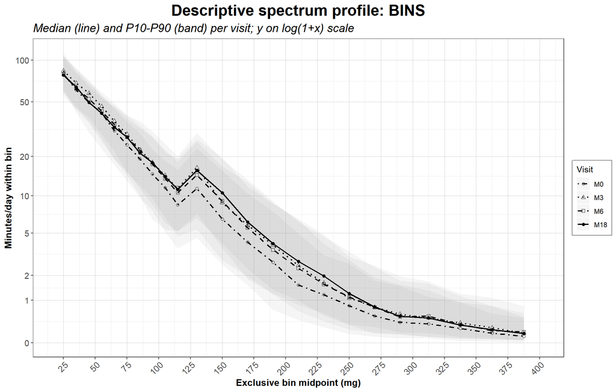

**What it shows.**

- The *raw* daily intensity profile: median minutes per day within each exclusive bin (line) and the 10th–90th percentile range (band), separately for each visit.
- The y-axis is compressed (log 1 + x) so that the few minutes at high intensity remain visible next to the hours at low intensity.

**Evaluation.**

- Time falls steeply with intensity: most of the day is spent below 100 mg, and above ~250 mg typical patients accumulate less than one minute per day per bin.
- The follow-up curves (M3, M6, M18) lie slightly but consistently above the baseline curve (M0, dot-dash) from roughly 70 mg upwards.
- This raw picture already anticipates the main result: a broad upward shift rather than a single peak.

**Caution:** Missing visits are not missing completely at random.

- Patients who later lack M18 tended to have larger M3 gains (S10).
- E1/E2 therefore use MMRM, which is valid under MAR. The M18 estimate is additionally stress-tested with a delta-adjusted tipping-point analysis (S9).
- Reasons for missing M0/M18 are not recorded in the master dataset.

# 4 Statistical methods, alternative models and independent review

## Models

**E1 and E2.** For each exclusive bin, and separately for each cumulative threshold, minutes/day are modelled with a mixed model for repeated measures:

- visit (M0, M3, M6, M18) is a fixed factor with an unstructured patient-level covariance (glmmTMB, REML);
- the outcome is scaled by its SD for numerical stability and back-transformed.

E1 is the visit contrast in min/day per 10 mg of bin width. E2 is the ratio of model-based marginal means (β₀ + βₓ)/β₀. When the unstructured model does not converge, a random-intercept model is used; such fallbacks are logged.

**E3.** Each recording is represented as a 21-part 24-h composition: <20 mg, 19 bins from 20 to 300 mg, and ≥300 mg. Zeros are replaced multiplicatively by 0.65 × one 5-s epoch per recording. The analysis then proceeds in three steps:

1. Mean paired changes in centred log-ratios are computed for every part.
2. For the bounded bins, these changes are regressed on log geometric-mean intensity with a natural spline (df = 3), which serves as the smooth null.
3. The residuals are the shape-departure estimand.

**Uncertainty.** A patient-level cluster bootstrap provides all intervals:

- one set of patient draws is shared by all estimands, bins, thresholds and visits;
- duplicated patients receive new cluster IDs, and the draws are pre-generated, so results do not depend on the number of workers.

From the bootstrap, the report shows pointwise percentile intervals and simultaneous 95% bands (max-t over the bins of a visit). Inner and outer confidence sets are derived from those bands.

## Decision rule

A **localised informative interval** is reported only when both hold:

- E3 residuals show a *bump*: at least 2 contiguous bins whose simultaneous band excludes zero, bounded on both sides by bins that do not, and touching neither grid edge;
- the bump is invariant to the zero-replacement value (epoch, 0.01, 0.5 min/day), to restricting to ≥5 valid days, and to excluding the UCTD/SSc patient.

Otherwise the report states that there is **no evidence of a localised departure**. It then adds either that the change is a smooth redistribution towards higher intensities (when the linear tilt is non-zero) or that shape change is not identifiable.

Coverage and magnitude are reported as separate descriptive dimensions, not as gates.

## Independent review

The plan was reviewed by a different model (Claude Fable 5.1). There were two review rounds, both with the verdict REVISE, and every objection was dispositioned:

- the full review: `docs/261013_phase3_independent_review.md`;
- the point-by-point disposition and locked plan v2: `docs/261013_phase3_disposition_and_locked_plan.md`.

Key changes:

- the claim that the high-intensity response is an SD artefact was withdrawn;
- E1 was normalised per 10 mg;
- E2 was made MAR;
- the shape estimand E3 with a smooth null was introduced;
- the gating decision rule was replaced by confidence sets;
- sliding windows were dropped.

# 5 Results — CUMULATIVE thresholds

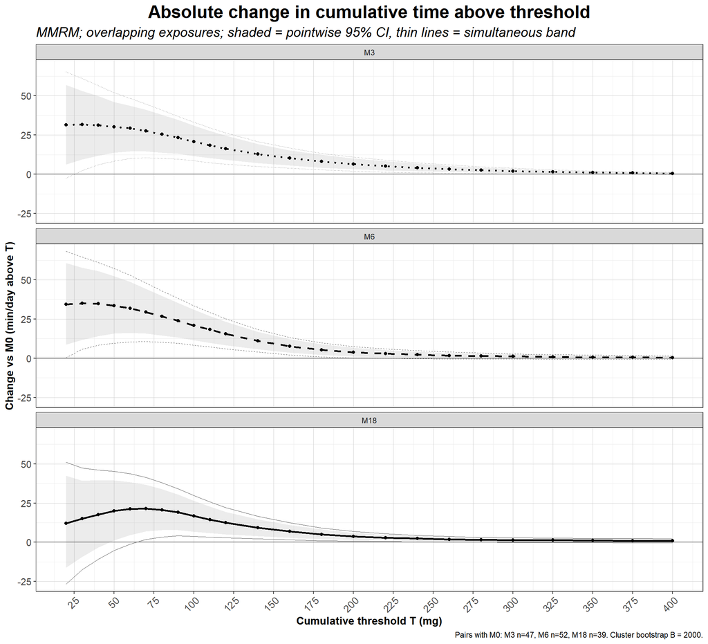

**What it shows.**

- How many more minutes per day patients spend *above* each threshold T at follow-up compared with M0, with 95% CI (shaded) and a simultaneous band (thin lines).
- “Above 100 mg” corresponds to the conventional GGIR “MVPA” threshold. This label is not a validated moderate-intensity category in myositis.

**Evaluation.**

- The gain is largest at low thresholds: above 40 mg, 31.2 (95% CI 11.8 to 49.9) min/day at M3. It decreases steadily with the threshold, because every higher threshold contains less time.
- Above 100 mg the gain is 20.9 and 21.0 min/day at M3 and M6, and 16.8 min/day at M18.
- Above 200 mg it is still 6.5 (95% CI 3.2 to 10.1) min/day at M3.

**Why it is interesting.**

- The gain above 100 mg is about a third more such time than at baseline (baseline median 51 min/day).
- It is still present at M18, under the missing-at-random assumption (see the tipping-point analysis).
- Whether a change of this size is clinically meaningful in IIM has not been established. That would need anchoring to function (for example MMT8, FI2, HAQ), which is outside the scope of this report.

**Caution:** Thresholds overlap: T100 contains everything above 100 mg, including the time above 200 mg. The curve therefore cannot tell *where* the change happens; the exclusive bins below answer that.

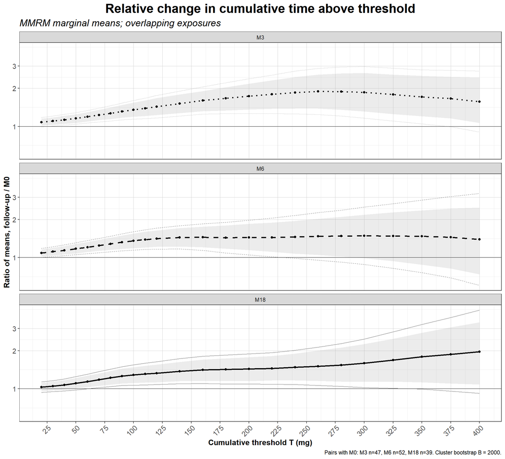

**What it shows.** The same comparison on a *relative* scale: follow-up time above T divided by M0 time above T (1 = no change). The y-axis is logarithmic.

**Evaluation.**

- Above 20 mg the relative change is small (+8 % at M3), because almost the whole waking day is above 20 mg.
- The relative gain at M3 rises with the threshold:
  - +35 % above 100 mg;
  - +74 % above 200 mg;
  - +86 % above 300 mg.
- The more intense the movement, the larger the *proportional* increase, even though the number of minutes involved is small.

**Note:** Cumulative thresholds are a complementary representation and are not used for localisation.

# 6 Results — exclusive BINS

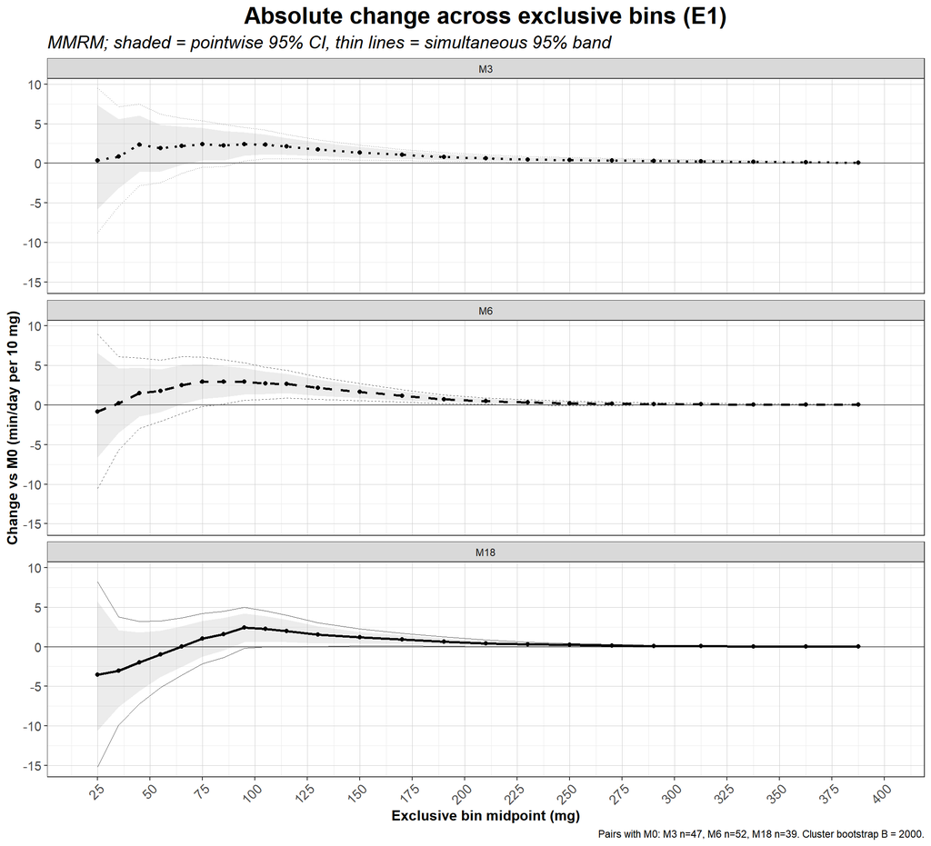

**What it shows.**

- The absolute change in minutes per day spent *within* each non-overlapping intensity bin, per 10 mg of bin width.
- Bins are 10, 20 or 25 mg wide; per-10 mg values make them comparable.
- **How to read:** an estimate of 2.5 at 90–100 mg means that patients spend on average 2.5 more minutes per day in that 10-mg slice of intensity than at baseline.

**Evaluation.**

- At M3 and M6, point estimates of the absolute gain are roughly 1.5–3 min/day per 10 mg from ~40 mg up to ~120 mg, tapering towards 200 mg.
  - 90–100 mg: 2.4 (95% CI 1.0 to 3.9) at M3 and 3.0 (95% CI 1.3 to 4.7) at M6.
- The simultaneous band excludes zero only from about 80–90 mg upwards: 90-300; 325-400 mg at M3 and 80-240 mg at M6.
- Below that, gains of similar size cannot be distinguished from zero. Low-intensity time varies far more between and within patients: the bootstrap SE is about 1.3–1.9 at 40–70 mg against about 0.8 at 90–100 mg.
- The lower edge of the “certain” range therefore reflects precision as much as the size of the change.
- At M18 the point estimates in the lowest bins (20–50 mg) are negative, but their CIs include zero, so no conclusion is possible there.

**Caution:** The 20–50 mg range in a 0–24 h analysis also contains restless sleep and very light movement. Changes there should not be interpreted as a change in a particular type of daytime activity.

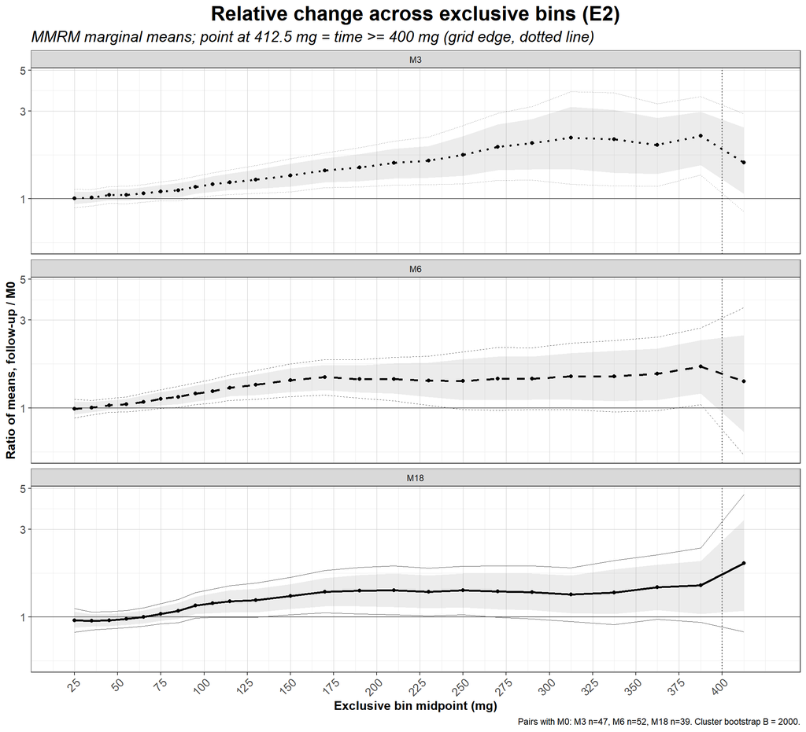

**What it shows.**

- The relative change within each bin: the ratio of mean minutes at follow-up to M0, from the same model (1 = no change).
- The last point (≥ 400 mg) is time above the top of the measured grid, so the dotted line marks where the measurement scale ends.

**Evaluation.**

- Below ~60 mg there is no relative change (ratio ≈ 1).
- From ~70 mg the ratio rises with intensity. At M3:
  - ×1.20 at 100–110 mg;
  - ×1.56 at 200–220 mg;
  - ×2.14 at 300–325 mg.
- At M6 and M18 the high-intensity ratios are smaller, about ×1.3–1.7.
- The simultaneous band excludes 1 over 80-240; 375-400 mg at M6 and only over 140-260 mg at M18.
- There is no peak followed by a decline that would mark an “optimal band”. The curve rises and then plateaus.

**Why it is interesting.**

- Time in the highest intensity bins roughly *doubles* in the early follow-up, but from a very low baseline of a few minutes per week per bin.
- This may reflect regained capacity for short, more demanding bouts of movement. Wrist ENMO has not been validated against activity type in IIM, so the kind of activity cannot be named.
- The upper limit of this effect cannot be determined because the GGIR grid ends at 400 mg.

E1 (min/day per 10 mg) and E2 (ratio of means) per exclusive bin

| Bin | Estimand | Visit | Estimate | 95% CI | Simult. band |
| --- | --- | --- | --- | --- | --- |
| 100-110 | E1 | M3 | 2.36 | 1.12 to 3.64 | 0.55 to 4.17 |
| 100-110 | E1 | M6 | 2.75 | 1.36 to 4.24 | 0.72 to 4.79 |
| 100-110 | E1 | M18 | 2.25 | 0.63 to 3.85 | -0.02 to 4.53 |
| 110-120 | E1 | M3 | 2.11 | 1.07 to 3.17 | 0.58 to 3.64 |
| 110-120 | E1 | M6 | 2.66 | 1.48 to 3.96 | 0.91 to 4.41 |
| 110-120 | E1 | M18 | 1.98 | 0.57 to 3.41 | -0.01 to 3.98 |
| 120-140 | E1 | M3 | 1.77 | 0.91 to 2.66 | 0.54 to 3.00 |
| 120-140 | E1 | M6 | 2.16 | 1.17 to 3.21 | 0.73 to 3.59 |
| 120-140 | E1 | M18 | 1.53 | 0.44 to 2.57 | 0.01 to 3.05 |
| 140-160 | E1 | M3 | 1.34 | 0.69 to 2.06 | 0.40 to 2.29 |
| 140-160 | E1 | M6 | 1.64 | 0.90 to 2.43 | 0.58 to 2.71 |
| 140-160 | E1 | M18 | 1.19 | 0.43 to 1.89 | 0.14 to 2.24 |
| 160-180 | E1 | M3 | 1.07 | 0.59 to 1.57 | 0.38 to 1.75 |
| 160-180 | E1 | M6 | 1.16 | 0.63 to 1.71 | 0.39 to 1.93 |
| 160-180 | E1 | M18 | 0.93 | 0.38 to 1.47 | 0.15 to 1.72 |
| 180-200 | E1 | M3 | 0.80 | 0.43 to 1.20 | 0.26 to 1.34 |
| 180-200 | E1 | M6 | 0.73 | 0.36 to 1.12 | 0.19 to 1.26 |
| 180-200 | E1 | M18 | 0.65 | 0.25 to 1.07 | 0.07 to 1.24 |
| 20-30 | E1 | M3 | 0.35 | -5.75 to 7.35 | -8.78 to 9.47 |
| 20-30 | E1 | M6 | -0.82 | -6.62 to 6.54 | -10.58 to 8.94 |
| 20-30 | E1 | M18 | -3.51 | -10.63 to 5.73 | -15.24 to 8.22 |
| 200-220 | E1 | M3 | 0.63 | 0.34 to 0.95 | 0.20 to 1.07 |
| 200-220 | E1 | M6 | 0.49 | 0.23 to 0.79 | 0.08 to 0.89 |
| 200-220 | E1 | M18 | 0.45 | 0.16 to 0.74 | 0.03 to 0.86 |
| 220-240 | E1 | M3 | 0.48 | 0.24 to 0.74 | 0.13 to 0.84 |
| 220-240 | E1 | M6 | 0.32 | 0.12 to 0.57 | 0.00 to 0.64 |
| 220-240 | E1 | M18 | 0.29 | 0.10 to 0.51 | 0.01 to 0.58 |
| 240-260 | E1 | M3 | 0.42 | 0.19 to 0.67 | 0.08 to 0.76 |
| 240-260 | E1 | M6 | 0.23 | 0.06 to 0.44 | -0.04 to 0.50 |
| 240-260 | E1 | M18 | 0.23 | 0.08 to 0.38 | 0.01 to 0.44 |

[output cut: 111 more lines]

**How to read.**

- E1 rows give minutes/day per 10 mg; E2 rows give the ratio of means.
- “Simult. band” is the conservative interval that keeps 95% coverage across all bins of a visit simultaneously. Use it when making statements about *which* bins changed.

# 7 Full-spectrum informativeness

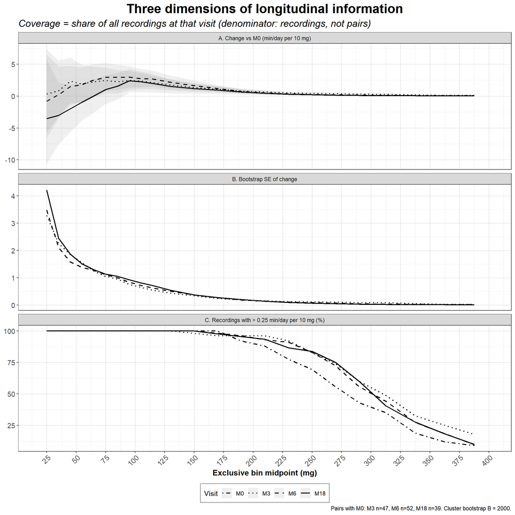

**What it shows.** Three properties of each bin side by side:

- **A**, how much change there is;
- **B**, how precisely it is estimated (bootstrap standard error; smaller = more precise);
- **C**, what percentage of recordings contain at least a minimal amount of time in that bin (> 0.25 min/day per 10 mg).

Panel C includes M0 as a reference.

**Evaluation.**

- Precision (B) is worst at the lowest intensities, where day-to-day and between-patient variation in sedentary and light time is large, and becomes very good above ~150 mg.
- Coverage (C) is ~100% up to ~200 mg and then drops.
- Coverage is consistently higher at follow-up than at baseline in the high bins: at 260–280 mg, 56 % of recordings at M0 against 74 % at M3.

**Why it is interesting.**

- A larger share of follow-up recordings than of baseline recordings contains measurable time at high intensities. Note that coverage compares different sets of recordings at each visit, not the same patients.
- Coverage and precision are highest where most of the daily time is spent. This is a property of the time distribution, not evidence for a preferred intensity band.

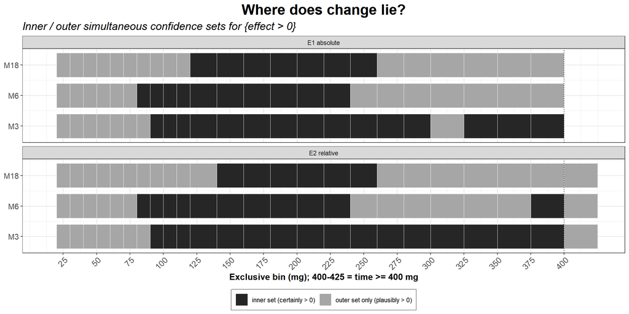

**How to read.**

- **Black** bins are those where the change is positive *with simultaneous 95% confidence*.
- **Grey** bins are those where a positive change is plausible but not proven.
- **White** bins would be those where even a positive change is not supported.

**Evaluation.**

- On the absolute scale the change is certainly positive over 90-300; 325-400 mg at M3, 80-240 mg at M6 and 120-260 mg at M18.
- Requiring at least +0.5 min/day per 10 mg narrows this to 100-140 mg at M3 and 90-160 mg at M6.
- These ranges mark where the change is *certainly* positive. Their lower edge (about 80–90 mg) reflects precision as much as size: below it, gains of similar size are estimated too imprecisely. They are therefore not a recommended band.

## Shape of change (E3)

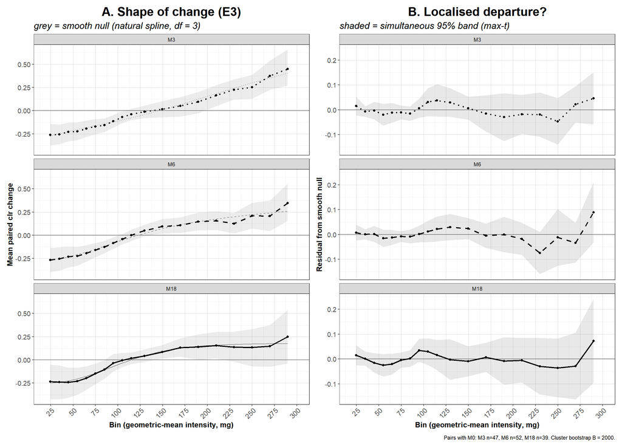

**What it shows.**

- **Panel A:** how each part of the 24-h day changes *relative to the rest of the day* (compositional, centred log-ratio). Negative values mean the part takes a smaller share of the day, positive values a larger share. The grey curve is the smooth trend.
- **Panel B:** what is left after removing that smooth trend. A genuine “special” intensity band would appear as a hump that rises clearly above zero, outside the shaded simultaneous band.

**Evaluation.**

- **Panel A:** at every visit the curve rises smoothly from negative (low intensities lose share) to positive (high intensities gain share).
  - The share of the day spent below 20 mg falls (M3 clr change -0.27 (95% CI -0.42 to -0.12)).
  - The share above 300 mg rises (0.37 (95% CI 0.17 to 0.59)).
- **Panel B:** the residuals stay within the band everywhere, so there is no localised hump.

**Why it is interesting.**

- This is the central result. Within the resolution of the test, improvement in IIM looks like a **“tilt” of the whole activity profile**: low-intensity bins lose relative share and high-intensity bins gain it.
- No intensity range stands out beyond this smooth tilt.
- **Resolution of the test:** localised extra gains of about +22% (+0.2 log), 2–6 bins wide, would very likely have been detected. Smaller departures of about +10% may be missed, particularly at M18 (see the power table in the validation section).
- Clinically, this favours describing recovery with profile-based measures together with a volume measure, rather than with a single new threshold.

E3 decision under the primary specification and all invariance variants

| Variant | Visit | Positive bumps | Negative bumps | Linear tilt (95% CI) | Verdict |
| --- | --- | --- | --- | --- | --- |
| primary_epoch | M3 |  |  | 0.28 (0.17 to 0.39) | no evidence of a localised departure; smooth redistribution towards higher intensities |
| primary_epoch | M6 |  |  | 0.25 (0.13 to 0.37) | no evidence of a localised departure; smooth redistribution towards higher intensities |
| primary_epoch | M18 |  |  | 0.22 (0.04 to 0.40) | no evidence of a localised departure; smooth redistribution towards higher intensities |
| zero_0.01 | M3 |  |  | 0.27 (0.16 to 0.39) | no evidence of a localised departure; smooth redistribution towards higher intensities |
| zero_0.01 | M6 |  |  | 0.25 (0.13 to 0.37) | no evidence of a localised departure; smooth redistribution towards higher intensities |
| zero_0.01 | M18 |  |  | 0.22 (0.04 to 0.40) | no evidence of a localised departure; smooth redistribution towards higher intensities |
| zero_0.5 | M3 |  |  | 0.30 (0.20 to 0.40) | no evidence of a localised departure; smooth redistribution towards higher intensities |
| zero_0.5 | M6 |  |  | 0.23 (0.12 to 0.35) | no evidence of a localised departure; smooth redistribution towards higher intensities |
| zero_0.5 | M18 |  |  | 0.21 (0.05 to 0.37) | no evidence of a localised departure; smooth redistribution towards higher intensities |
| S7_validdays5 | M3 |  |  | 0.32 (0.22 to 0.43) | no evidence of a localised departure; smooth redistribution towards higher intensities |
| S7_validdays5 | M6 |  |  | 0.25 (0.13 to 0.38) | no evidence of a localised departure; smooth redistribution towards higher intensities |
| S7_validdays5 | M18 |  |  | 0.21 (0.01 to 0.40) | no evidence of a localised departure; smooth redistribution towards higher intensities |
| S8_no_UCTD | M3 |  |  | 0.28 (0.17 to 0.39) | no evidence of a localised departure; smooth redistribution towards higher intensities |
| S8_no_UCTD | M6 |  |  | 0.25 (0.13 to 0.37) | no evidence of a localised departure; smooth redistribution towards higher intensities |
| S8_no_UCTD | M18 |  |  | 0.22 (0.04 to 0.40) | no evidence of a localised departure; smooth redistribution towards higher intensities |

**Evaluation.**

- The verdict “no localised departure; smooth redistribution” is identical across all variants:
  - three choices of how zero minutes are handled;
  - restriction to ≥ 5 valid days;
  - exclusion of the patient with UCTD/SSc.
- The *linear tilt* (how strongly the profile rotates towards higher intensities) is positive at every visit:
  - largest at M3: 0.28 (95% CI 0.17 to 0.39);
  - smaller at M6 (0.25 (95% CI 0.13 to 0.37)) and M18 (0.22 (95% CI 0.04 to 0.40)).

## Heterogeneity and timing (C1, C3, C5)

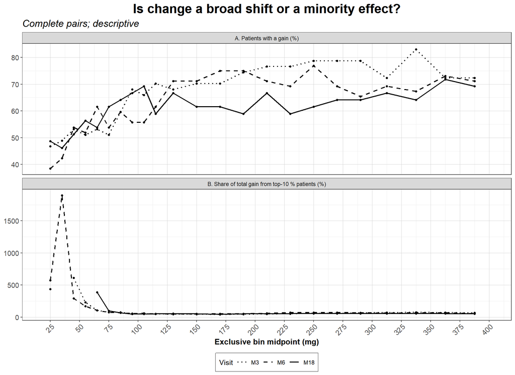

**What it shows.**

- **Panel A:** the percentage of patients whose time in a bin increased.
- **Panel B:** how much of the cohort’s total gain comes from the 10% of patients with the largest gains. If the gain were shared equally, panel B would be ~10%.

**Evaluation.**

**Why it is interesting.**

- The improvement is *broad*: most patients move up the intensity scale.
- The high-intensity part of the gain, however, is driven by a *minority of strong responders*.
- Identifying who these responders are is a natural next clinical question. Possible factors are subtype, disease duration, treatment intensity and baseline strength.

C5 — Is the change captured by a smooth tilt (intensity gradient)?

| Visit | n | Mean ΔIG | Mean Δ mean ENMO (mg) | Mean clr tilt | Spearman tilt vs ΔIG | Spearman tilt vs Δ ENMO |
| --- | --- | --- | --- | --- | --- | --- |
| M3 | 47 | 0.05 | 3.00 | 0.28 | 0.68 | 0.43 |
| M6 | 52 | 0.08 | 3.13 | 0.25 | 0.69 | 0.53 |
| M18 | 39 | 0.11 | 2.67 | 0.22 | 0.71 | 0.62 |

**What it shows.**

- Whether the patient-level “tilt” of the profile (from E3) moves together with established summary metrics: the change in intensity gradient (ΔIG) and the change in mean acceleration (Δ mean ENMO).
- A Spearman correlation of 1 would mean they carry identical information.

**Evaluation.**

- The tilt correlates moderately with ΔIG (ρ ≈ 0.69 at M6) and less strongly with Δ mean ENMO (ρ ≈ 0.53).
- Mean ENMO rose by about 3.1 mg at M6.
- The two measures diverge at group level: mean ΔIG *increases* from M3 to M18 (0.048 → 0.105), while the clr tilt *decreases* (0.277 → 0.218).
- A plausible reason is that GGIR computes IG over a wider range (0–4000 mg in 25-mg bins) than this analysis (20–400 mg).

**Why it is interesting.**

- IG is a closely related, cut-point-free summary of the same tilt. Both are slopes of log time against log intensity, so some correlation is expected by construction.
- A ρ of about 0.7 means the two share only about half of the between-patient ranking, and their time courses differ.
- IG is therefore a reasonable but **not equivalent** summary.
- For studies in IIM, a combination of a volume measure (mean ENMO or time above a conventional threshold) and IG is well justified. The spectrum profile is the more detailed descriptive complement.

C1 — Does the shape of change differ between M3 and M6 (same patients)?

| Part | M6 − M3 clr change | 95% CI | Simult. band | Patients |
| --- | --- | --- | --- | --- |
| <20 | -0.06 | -0.20 to 0.08 | -0.26 to 0.14 | 45 |
| 20-30 | -0.05 | -0.16 to 0.08 | -0.22 to 0.13 | 45 |
| 30-40 | -0.03 | -0.14 to 0.09 | -0.19 to 0.13 | 45 |
| 40-50 | -0.03 | -0.12 to 0.08 | -0.17 to 0.12 | 45 |
| 50-60 | -0.02 | -0.10 to 0.07 | -0.15 to 0.11 | 45 |
| 60-70 | -0.01 | -0.09 to 0.08 | -0.13 to 0.11 | 45 |
| 70-80 | 0.01 | -0.06 to 0.08 | -0.09 to 0.11 | 45 |
| 80-90 | 0.03 | -0.03 to 0.09 | -0.05 to 0.11 | 45 |
| 90-100 | 0.03 | -0.02 to 0.09 | -0.04 to 0.11 | 45 |
| 100-110 | 0.03 | -0.02 to 0.08 | -0.04 to 0.10 | 45 |
| 110-120 | 0.04 | -0.02 to 0.10 | -0.04 to 0.13 | 45 |
| 120-140 | 0.06 | -0.00 to 0.12 | -0.03 to 0.14 | 45 |
| 140-160 | 0.08 | 0.00 to 0.15 | -0.03 to 0.18 | 45 |
| 160-180 | 0.07 | -0.01 to 0.15 | -0.05 to 0.18 | 45 |
| 180-200 | 0.05 | -0.06 to 0.17 | -0.12 to 0.22 | 45 |
| 200-220 | 0.01 | -0.09 to 0.12 | -0.14 to 0.17 | 45 |
| 220-240 | -0.08 | -0.18 to 0.03 | -0.22 to 0.07 | 45 |
| 240-260 | -0.03 | -0.19 to 0.12 | -0.25 to 0.20 | 45 |
| 260-280 | -0.13 | -0.28 to 0.00 | -0.34 to 0.08 | 45 |
| 280-300 | -0.10 | -0.25 to 0.05 | -0.31 to 0.12 | 45 |
| >=300 | 0.11 | -0.08 to 0.28 | -0.14 to 0.36 | 45 |

Pre-specified per-subtype summaries (complete pairs; PM and UCTD/SSc excluded; descriptive)

| Subtype | Visit | Pairs | ΔT100 mean (min/day) | ΔT100 median [IQR] | Patients with T100 gain (%) | clr tilt mean | ΔIG mean |
| --- | --- | --- | --- | --- | --- | --- | --- |
| ASyS | M3 | 14 | 21.83 | 20.9 [-2.1; 43.6] | 64.29 | 0.21 | 0.03 |
| DM | M3 | 17 | 24.22 | 24.6 [-0.5; 42.9] | 70.59 | 0.27 | 0.04 |
| IMNM | M3 | 13 | 8.53 | 5.7 [-5.0; 20.5] | 61.54 | 0.32 | 0.07 |
| ASyS | M6 | 15 | 33.86 | 24.2 [0.9; 62.0] | 73.33 | 0.16 | 0.01 |
| DM | M6 | 18 | 23.50 | 24.4 [1.5; 45.5] | 72.22 | 0.29 | 0.08 |
| IMNM | M6 | 15 | 5.08 | 3.0 [-3.6; 14.9] | 66.67 | 0.28 | 0.13 |
| ASyS | M18 | 12 | 22.94 | 21.1 [3.4; 41.4] | 75.00 | 0.17 | 0.05 |
| DM | M18 | 14 | 31.02 | 38.8 [-5.1; 65.0] | 64.29 | 0.30 | 0.16 |
| IMNM | M18 | 13 | 1.67 | -5.9 [-9.6; 14.1] | 46.15 | 0.18 | 0.10 |

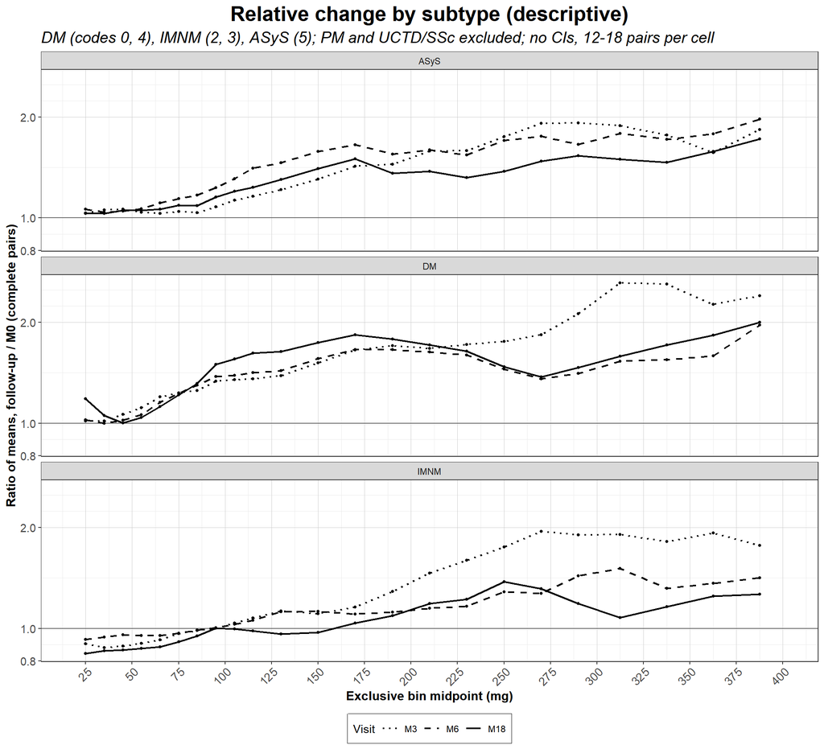

**What it shows.**

- Three pre-specified summaries per subtype:
  - change in time above 100 mg (mean, median with IQR, % of patients with a gain);
  - the patient-level clr tilt;
  - the change in IG.
- F7 shows the full bin-by-bin relative profile per subtype.
- Purely descriptive: no CIs and no tests, 12–18 pairs per subtype and visit.

**Evaluation.**

- The summaries differ in size between DM, IMNM and ASyS.
- Within each subtype, medians and IQRs show wide individual variation, so a small mean does not mean that no patient improved.

**Why it is interesting.**

- Differences in recovery of daily activity between myositis subtypes are clinically plausible. With these sample sizes, however, any difference could be due to chance, to baseline severity, disease duration or treatment.
- A pre-specified, adequately powered subtype analysis adjusted for these factors is a natural next study.

**Caution:** No inference about subtype effects should be drawn from this table or figure. Any single bin or subtype highlighted after looking at the data would be a post-hoc selection.

**What it shows.**

- In patients with all three visits (M0, M3, M6), it compares whether the *shape* of change differs between the early (M3) and later (M6) follow-up.
- Positive values mean that bin gained more share by M6 than by M3.

**Evaluation.**

- Point estimates suggest a shift:
  - from M3 to M6, the 120–180 mg range gains share (for example 0.077 at 140–160 mg);
  - the 220–300 mg range loses share (-0.131 at 260–280 mg).
- None of the bins is significant within the simultaneous band.
- **Interpretation:** a hypothesis of early high-intensity emphasis followed by consolidation in the moderate range, subject to the timing and season caveats below. A larger cohort is needed to confirm it.
- **Alternative explanations to rule out first:**
  - M3 and M6 overlap in timing (2–6 vs 4–9 months after M0);
  - the two visits differ in season contrast: M0→M3 is about a quarter-year shift, and no M0→M6 pair falls in the same season.

# 8 Robustness, validation results and discrepancy log

## Sensitivity analyses

Agreement of sensitivity analyses with the primary E1/E2 estimates

| Estimand | Block | Sensitivity | n | Same sign as primary (%) | Within primary 95% CI (%) |
| --- | --- | --- | --- | --- | --- |
| E1 | bins | S1 complete pairs | 69 | 94.2 | 100 |
| E1 | bins | S2 random intercept | 69 | 98.6 | 100 |
| E1 | bins | S7 >= 5 valid days | 69 | 98.6 | 100 |
| E1 | bins | S8 without UCTD/SSc | 69 | 98.6 | 100 |
| E1 | cumulative | S1 complete pairs | 72 | 100.0 | 100 |
| E1 | cumulative | S2 random intercept | 72 | 100.0 | 100 |
| E1 | cumulative | S7 >= 5 valid days | 72 | 100.0 | 100 |
| E1 | cumulative | S8 without UCTD/SSc | 72 | 100.0 | 100 |
| E2 | bins | S1 complete pairs | 69 | 94.2 | 100 |
| E2 | bins | S2 random intercept | 69 | 98.6 | 100 |
| E2 | bins | S7 >= 5 valid days | 69 | 98.6 | 100 |
| E2 | bins | S8 without UCTD/SSc | 69 | 98.6 | 100 |
| E2 | cumulative | S1 complete pairs | 72 | 100.0 | 100 |
| E2 | cumulative | S2 random intercept | 72 | 100.0 | 100 |
| E2 | cumulative | S7 >= 5 valid days | 72 | 100.0 | 100 |
| E2 | cumulative | S8 without UCTD/SSc | 72 | 100.0 | 100 |

**Evaluation.**

- Under alternative analyses the estimates keep their direction in 94–100% of bins and stay within the primary 95% CI in 100% of bins. The alternatives are complete pairs only, a simpler random-intercept model, ≥ 5 valid days, and exclusion of the UCTD/SSc patient.
- **The main results are consistent under these analytic choices.** Containment within the primary CI is weak evidence, because all variants share most of the data.

Seasonality anchor test (joint 2-df LRT of annual harmonics, corrected)

| block | descriptor | n_obs | n_patients | months_observed | LR_chisq | LR_df | LR_p | sin_beta | cos_beta |
| --- | --- | --- | --- | --- | --- | --- | --- | --- | --- |
| cumulative | T100 | 217 | 71 | 12 | 4.109 | 2 | 0.128 | 0.021 | -0.076 |
| bins | 100-110 | 217 | 71 | 12 | 3.853 | 2 | 0.146 | 0.024 | -0.049 |

**What it shows.** A test of whether time of year (an annual sine/cosine cycle) explains part of the activity level. It is run for time above 100 mg and for the 100–110 mg bin.

**Evaluation.**

- There is no evidence of a seasonal effect (p ≈ 0.13). Season-adjusted models gave virtually the same visit effects.
- The previously empty seasonality sheet in A04/A07 was caused by a coding error that is now fixed.

**Caution:** Visits are tied to the calendar: no M0→M6 pair falls in the same season. Seasonal and treatment effects therefore cannot be fully separated, and a null seasonal test does not exclude a modest seasonal contribution.

S9 — How much worse would missing M18 values have to be to remove the M0→M18 gain?

| Bin | Patients with M0 | M18 imputed | δ: point estimate → 0 | δ: lower 95% bound → 0 |
| --- | --- | --- | --- | --- |
| 100-110 | 63 | 24 | 6.65 | 1.65 |
| 110-120 | 63 | 24 | 5.72 | 1.49 |
| 120-140 | 63 | 24 | 4.41 | 1.14 |
| 140-160 | 63 | 24 | 3.24 | 1.12 |
| 160-180 | 63 | 24 | 2.45 | 0.99 |
| 180-200 | 63 | 24 | 1.65 | 0.66 |
| 20-30 | 63 | 24 | -3.60 | -27.90 |
| 200-220 | 63 | 24 | 1.13 | 0.43 |
| 220-240 | 63 | 24 | 0.75 | 0.26 |
| 240-260 | 63 | 24 | 0.59 | 0.20 |
| 260-280 | 63 | 24 | 0.39 | 0.11 |
| 280-300 | 63 | 24 | 0.28 | 0.07 |
| 30-40 | 63 | 24 | -5.41 | -20.01 |
| 300-325 | 63 | 24 | 0.18 | 0.03 |
| 325-350 | 63 | 24 | 0.14 | 0.02 |
| 350-375 | 63 | 24 | 0.13 | 0.03 |
| 375-400 | 63 | 24 | 0.11 | 0.01 |
| 40-50 | 63 | 24 | -4.29 | -14.71 |
| 50-60 | 63 | 24 | -1.61 | -10.08 |
| 60-70 | 63 | 24 | 0.91 | -6.71 |
| 70-80 | 63 | 24 | 3.63 | -3.22 |
| 80-90 | 63 | 24 | 5.01 | -1.31 |
| 90-100 | 63 | 24 | 7.17 | 1.51 |

**What it shows.**

- Roughly 4 in 10 patients with a baseline have no M18 recording.
- The tipping point is how much *worse* their unobserved M18 values would have to be, compared with what the model predicts, before the M0→M18 gain disappears.

**Evaluation.**

## Validation (PASS/WARN/FAIL)

Validation plan results

| ID | Check | Status | Detail |
| --- | --- | --- | --- |
| V1 | Data integrity checks (D1–D19) | PASS | 10 PASS, 4 WARN, 0 FAIL |
| V2 | Paired change: cumulative T = sum of bins >= T + (>=400) | PASS | max &#124;error&#124; = 3.55e-15 min/day (identity holds for complete pairs; MMRM per descriptor is not additive by construction) |
| V3 | Composition closes to 1440 min (raw and after zero replacement); bins = native GGIR edges | PASS | max &#124;sum-1440&#124; raw 0.0e+00, replaced 0.0e+00; 21 parts |
| V4 | Reproducibility: same input = same estimates; bootstrap 1 vs N workers identical | PASS | estimates identical: TRUE; 1 vs 4 workers identical: TRUE; seed 20261013 |
| V5a | MMRM convergence across bootstrap replicates | PASS | replicate x visit fits: random-intercept fallback 0, failed 0 (see fit_log) |
| V5b | Residual distribution (RI LMM, per bin) | WARN | max &#124;skewness&#124; 5.07, max excess kurtosis 43.1, max Spearman(&#124;r&#124;, fitted) 0.57 -> uncertainty from cluster bootstrap, not Wald |
| V6 | Leave-one-patient-out influence on E1 (in SE units) | PASS | max shift 0.93 SE (median 0.47 SE); bins/visits with shift > 1 SE: 0 |
| V7a | Matrix E3 engine = est_E3() (observed residuals) | PASS | max &#124;difference&#124; = 2.9e-16 |
| V7 | Power of E3 bump rule, true-null plasmode (N_SIM = 500, B_SIM = 1000) | INFO | 2 bins 120-160, +0.2 M3: 100%; 2 bins 120-160, +0.2 M6: 100%; 2 bins 120-160, +0.2 M18: 97%; 2 bins 120-160, +0.1 M3: 68%; 2 bins 120-160, +0.1 M6: 77%; 2 bins 120-160, +0.1 M18: 35%; 3 bins 180-240, … |
| V7b | Type-I rate of the bump rule under a true null (nominal <= 5%) | PASS | M3: 2.0% (MC 95% CI 1-4); M6: 0.6% (MC 95% CI 0-2); M18: 0.8% (MC 95% CI 0-2) |

**What it shows.** Automatic checks of the computations:

- arithmetic identities;
- reproducibility (the same result on 1 or many CPU cores);
- model convergence (all models converged);
- residual distribution;
- influence of single patients.

**Evaluation.**

- All technical checks pass.
- Residuals are skewed (WARN), which is expected for minutes-per-day data. This is why all confidence intervals come from the patient bootstrap, not from model formulas.
- No single patient shifts any estimate by more than about one standard error.

Plasmode power of the E3 bump rule (+0.2 log bump injected at follow-up)

| Scenario | Visit | Simulations | Any bump flagged (%) | Injected bump detected (%) |
| --- | --- | --- | --- | --- |
| null (true null) | M3 | 500 | 2 |  |
| null (true null) | M6 | 500 | 1 |  |
| null (true null) | M18 | 500 | 1 |  |
| 2 bins 120-160, +0.2 | M3 | 500 | 100 | 100 |
| 2 bins 120-160, +0.2 | M6 | 500 | 100 | 100 |
| 2 bins 120-160, +0.2 | M18 | 500 | 99 | 97 |
| 2 bins 120-160, +0.1 | M3 | 500 | 73 | 68 |
| 2 bins 120-160, +0.1 | M6 | 500 | 79 | 77 |
| 2 bins 120-160, +0.1 | M18 | 500 | 37 | 35 |
| 3 bins 180-240, +0.2 | M3 | 500 | 93 | 88 |
| 3 bins 180-240, +0.2 | M6 | 500 | 100 | 100 |
| 3 bins 180-240, +0.2 | M18 | 500 | 93 | 87 |
| 4 bins 80-120, +0.2 | M3 | 500 | 100 | 100 |
| 4 bins 80-120, +0.2 | M6 | 500 | 100 | 100 |
| 4 bins 80-120, +0.2 | M18 | 500 | 100 | 100 |
| 4 bins 80-120, +0.1 | M3 | 500 | 95 | 92 |
| 4 bins 80-120, +0.1 | M6 | 500 | 99 | 98 |
| 4 bins 80-120, +0.1 | M18 | 500 | 79 | 75 |
| 6 bins 70-140, +0.2 | M3 | 500 | 100 | 100 |
| 6 bins 70-140, +0.2 | M6 | 500 | 100 | 100 |
| 6 bins 70-140, +0.2 | M18 | 500 | 100 | 100 |
| 6 bins 70-140, +0.1 | M3 | 500 | 74 | 53 |
| 6 bins 70-140, +0.1 | M6 | 500 | 94 | 76 |
| 6 bins 70-140, +0.1 | M18 | 500 | 71 | 49 |

**What it shows.**

**Evaluation.**

- **False alarms under the true null:** M3 2.0% (MC 95% CI 1-4%); M6 0.6% (MC 95% CI 0-2%); M18 0.8% (MC 95% CI 0-2%). A calibrated rule keeps these at or below the nominal 5%.
- **Large departures (+22%) are detected reliably**, narrow or broad:
  - 2 bins at 120–160 mg: 97–100 %;
  - 3 bins at 180–240 mg: 87–100 %;
  - 4 bins at 80–120 mg: 100 %;
  - 6 bins at 70–140 mg: 100 %.
- **Small departures (+10%) are detected less reliably**, and least at M18 (n = 39):
  - 2 bins: 35–77 %;
  - 4 bins: 75–98 %;
  - 6 bins: 49–76 %.
  - For broad small humps the smooth null absorbs part of the departure.
- **The rule does not over-detect**: false alarms stayed at or below the nominal 5%, including at M18 (n = 39). This calibrates the bump rule. It does not by itself verify the coverage of every individual simultaneous band.
- **Conclusion on scope:** the absence of a localised band is well supported for departures of about +22% or more. Departures of about +10%, particularly broad ones or at M18, cannot be excluded, and when flagged they may be mislocalised: for a +10% 6-bin bump, *some* bump was flagged more often than the flag overlapped the injected bins.

## Discrepancy / issue log

Issue log (audit → fix → impact)

id

observation

severity

cause

test

fix

impact

K1

Earlier claim: high-intensity M3 peak is an SD artefact

critical (scientific)

scale-dependent location of maxima

relative (E2), dz (E4), clr (E3) profiles

claim withdrawn; estimands chosen a priori

interpretation H1 revised

K2

Revised R00 hard-codes R:/ path, ignores MYOII_MASTER_RDS

critical (reproducibility)

regression in revised helper

code review

new config with lookup order + env override

old R05/R06 not portable

K3

season_anchor_test sheet empty in A04/A07

high

anova.merMod column is Df, not `Chi Df`

xlsx inspection + code

fixed in season_anchor_test()

seasonality test now available (S5)

V1

Bootstrap results depend on worker count (R03/R06)

high

clusterSetRNGStream + parLapply

1 vs N workers

draws pre-generated in main process

results portable across machines

V2

R05 bootstrap per visit x bin, not per patient across spectrum

high

group_modify resampling

code review

one draw for all bins/visits

simultaneous bands now valid

MO2

Absolute peak at 120-140 mg is a bin-width artefact

major

bins 10/20/25 mg

per-10 mg normalisation

E1 per 10 mg

absolute peak 90-100 mg

MO4

Zeros concentrated at M0 in 375-400 mg (14%)

major

sparse tail

zero tables by visit

>=300 mg amalgamated for E3; replacement grid

E3 tail stable

MO5

Trajectory-dependent dropout to M18

major

observational follow-up

S10

MMRM (MAR) primary; tipping point S9

M18 interpreted with caveat

R1

Linear trend null produces U-shaped residuals

major

S-shaped change profile

observed residual signs

natural-spline null, bump rule

no false edge ‘intervals’

MO9

L/R wrist labels differ within 10 patients

info

filename labels (device always non-dominant per user)

filename parsing

none (documented)

none expected

R3-5

‘Null’ plasmode resampled observed data (not a true null); small N_SIM/B_SIM

major

simulation design

true-null plasmode, N_SIM 500 x B_SIM 1000, MC CI

V7 rewritten (matrix engine)

type-I rate now estimable

R3-6

Spline df = 3 null may absorb broad bumps; detection matched edge strings

major

smooth null resolution

4- and 6-bin scenarios; overlap-based detection

V7 scenarios extended

E3 conclusion limited to the tested resolution

R3-7

Tipping point E/p is a mechanical identity

major

definition on point estimate

algebra

report delta at which the 95% lower bound reaches 0

M18 robustness re-stated

R3-11

IMNM single-bin highlight was post hoc

major

selection from 23 x 3 x 3 cells

pre-specified per-subtype summaries (T100, tilt, dIG) + full profiles

subtype text reframed

**What it shows.** Every problem found in the earlier analyses (A04/A07, R01–R06), with its cause, the fix and the effect on conclusions.

**The most important one for interpretation.** In the earlier analyses the location of the maximum depended on the scale (SD units, minutes, ratios). The high-intensity relative response is real, but it is small in absolute minutes and concentrated in a minority of patients. The analysis now reports absolute, relative and shape estimands separately.

# 9 Biological and clinical interpretation

**Caution:** ENMO in mg is not a metabolic intensity (MET), and the GGIR ‘MVPA’ naming does not imply validated intensity categories for this population.

- Changes in time within bins describe *where on the acceleration scale* daily movement increased.
- They do not show *why* it increased: clinical response, season, or behaviour.

Testable hypotheses (exploratory; to be confirmed in independent data):

1. **H1:** Improvement in IIM is expressed mainly as a **smooth tilt** of the daily intensity distribution towards higher accelerations, rather than as a gain in one specific intensity band. Small (~10%) localised departures cannot be excluded with these data.
2. **H2:** Absolute minutes are gained mostly in the intermediate range, where most of the daily active time lies. Relative gains are largest at high intensities, but there they amount to fractions of a minute per day.
3. **H3:** High-intensity relative gains are carried by a **minority** of patients (see the top-10 % share). The median gain is substantially smaller than the mean.
4. **H4:** The early (M3) and later (M6/M18) responses differ in shape (C1). This would be compatible with a time-dependent recovery pattern, but visit timing and season must be controlled for, and it should be tested prospectively.

# 10 Limitations

1. **Missing data and selection.**
   - Follow-up is incomplete and dropout is related to the trajectory.
   - MMRM (MAR) and the tipping-point analysis mitigate this but cannot exclude MNAR.
   - Reasons for missingness are not available.
2. **No within-person reliability.**
   - Group-level precision (bootstrap SE) is not test-retest reliability.
   - Smallest detectable change per bin requires GGIR day-level data.
3. **Fixed, irregular GGIR threshold grid with an upper edge at 400 mg.**
   - Regions cannot be resolved more finely than the native bins (10–25 mg).
   - The upper limit of high-intensity relative change is censored by the grid.
   - Season is structurally linked to visit timing, which limits seasonal adjustment.
4. **Resolution of the shape test.**
   - Localised departures of about +22% (2–6 bins) would very likely have been detected.
   - Departures of about +10% may have been missed, particularly broad ones and at M18 (see the power simulation).

**TODO:** Request GGIR `part2_daysummary*.csv` and `config.csv`. These are needed for a reliability module and for documenting the valid-day criteria.

# 11 Conclusions, next research questions and reproducibility

**Conclusion per visit (pre-specified rule):**

- M18: no evidence of a localised departure; smooth redistribution towards higher intensities
- M3: no evidence of a localised departure; smooth redistribution towards higher intensities
- M6: no evidence of a localised departure; smooth redistribution towards higher intensities

**Next questions** (not implemented without explicit agreement):

- association of spectrum change with MMT8 / FI2 / HAQ;
- subtype-specific profiles (DM / IMNM / ASyS) with adequate sample size;
- reliability from day-level data.

**Reproducibility.** Run the scripts in `working/` in order 01 → 06, then knit this report (see `README.md`). Everything is read from the master RDS, whose path and md5 are listed below. Bootstrap B, seed and number of workers are stored with the results.

Run metadata

| Item | Value |
| --- | --- |
| Master RDS | F:/Analysis/Vernerová Lucia/myo_2025_iim/data/threshold/MYOII_ACC_OUTCOMES_MASTER_V1.rds |
| md5 | a4821db9803a46c31eb4dc6639add5b9 |
| Master built by | unknown |
| Bootstrap B | 2000 |
| Seed | 20261013 |
| Workers | 31 |
| Failed replicates | 0 |

# 12 References

The bibliographic details below are taken from the independent reviewer’s list or the earlier materials. Items marked *(to verify)* must be checked against PubMed or the publisher before submission.

1. Rowlands AV, Edwardson CL, Davies MJ, et al. Beyond cut points: accelerometer metrics that capture the physical activity profile. *Med Sci Sports Exerc* 2018;50:1323–1332. doi:10.1249/MSS.0000000000001561.
2. Rowlands AV, Dawkins NP, Maylor B, et al. Enhancing the value of accelerometer-assessed physical activity: meaningful visual comparisons of data-driven translational accelerometer metrics. *Sports Med Open* 2019;5:47. doi:10.1186/s40798-019-0225-9 *(to verify)*.
3. Migueles JH, Rowlands AV, Huber F, Sabia S, van Hees VT. GGIR: a research community-driven open source R package for generating physical activity and sleep outcomes from multi-day raw accelerometer data. *J Meas Phys Behav* 2019;2:188–196. doi:10.1123/jmpb.2018-0063.
4. Hildebrand M, van Hees VT, Hansen BH, Ekelund U. Age group comparability of raw accelerometer output from wrist- and hip-worn monitors. *Med Sci Sports Exerc* 2014;46:1816–1824. doi:10.1249/MSS.0000000000000289.
5. Chastin SFM, Palarea-Albaladejo J, Dontje ML, Skelton DA. Combined effects of time spent in physical activity, sedentary behaviors and sleep on obesity and cardio-metabolic health markers: a novel compositional data analysis approach. *PLoS One* 2015;10:e0139984. doi:10.1371/journal.pone.0139984.
6. Dumuid D, Stanford TE, Martín-Fernández JA, et al. Compositional data analysis for physical activity, sedentary time and sleep research. *Stat Methods Med Res* 2018;27:3726–3738. doi:10.1177/0962280217710835 *(to verify)*.
7. Sommerfeld M, Sain S, Schwartzman A. Confidence regions for spatial excursion sets from repeated random field observations. *J Am Stat Assoc* 2018;113:1327–1340. doi:10.1080/01621459.2017.1341838 *(to verify)*.
8. Westfall PH, Young SS. *Resampling-Based Multiple Testing*. Wiley; 1993.
9. Field CA, Welsh AH. Bootstrapping clustered data. *J R Stat Soc B* 2007;69:369–390. doi:10.1111/j.1467-9868.2007.00593.x *(to verify)*.
10. Brooks ME, Kristensen K, van Benthem KJ, et al. glmmTMB balances speed and flexibility among packages for zero-inflated generalized linear mixed modeling. *R Journal* 2017;9:378–400. doi:10.32614/RJ-2017-066.
11. Mallinckrodt CH, et al. Recommendations for the primary analysis of continuous endpoints in longitudinal clinical trials. *Drug Inf J* 2008;42:303–319 *(to verify)*.

# 13 Session info

**Platform**

R environment

| Setting | Value |
| --- | --- |
| version | R version 4.6.1 (2026-06-24 ucrt) |
| os | Windows 11 x64 (build 26300) |
| system | x86_64, mingw32 |
| ui | RStudio |
| language | (EN) |
| collate | Czech_Czechia.utf8 |
| ctype | Czech_Czechia.utf8 |
| tz | Europe/Prague |
| date | 2026-10-14 |
| rstudio | 2026.09.0+174 Autumn Hawkbit (desktop) |
| pandoc | 3.10 @ F:/R/RStudio/resources/app/bin/quarto/bin/tools/ (via rmarkdown) |
| quarto | 1.10.18 @ F:.exe |

**Used packages**

| package | loadedversion | date | attached |
| --- | --- | --- | --- |
| BiocManager | 1.30.27 | 2025-11-14 | FALSE |
| boot | 1.3-32 | 2025-08-29 | FALSE |
| bslib | 0.12.0 | 2026-08-04 | FALSE |
| cachem | 1.1.0 | 2024-05-16 | FALSE |
| cellranger | 1.1.0 | 2016-07-27 | FALSE |
| cli | 3.6.6 | 2026-04-09 | FALSE |
| codetools | 0.2-20 | 2024-03-31 | FALSE |
| conflicted | 1.2.0 | 2023-02-01 | TRUE |
| digest | 0.6.39 | 2025-11-19 | FALSE |
| dplyr | 1.2.1 | 2026-04-03 | TRUE |
| evaluate | 1.0.5 | 2025-08-27 | FALSE |
| farver | 2.1.2 | 2024-05-13 | FALSE |
| fastmap | 1.2.0 | 2024-05-15 | FALSE |
| forcats | 1.0.1 | 2025-09-25 | TRUE |
| furrr | 0.4.0 | 2026-03-31 | FALSE |
| future | 1.76.0 | 2026-09-24 | TRUE |
| generics | 0.1.4 | 2025-05-09 | FALSE |
| ggplot2 | 4.0.3 | 2026-04-22 | TRUE |
| glmmTMB | 1.1.15.2 | 2026-09-29 | FALSE |
| globals | 0.20.0 | 2026-10-11 | FALSE |
| glue | 1.8.1 | 2026-04-17 | FALSE |
| gridExtra | 2.3.1 | 2026-06-25 | TRUE |
| gtable | 0.3.6 | 2024-10-25 | FALSE |
| hms | 1.1.4 | 2025-10-17 | FALSE |
| htmltools | 0.5.9 | 2025-12-04 | FALSE |
| janitor | 2.2.1 | 2024-12-22 | TRUE |
| jquerylib | 0.1.4 | 2021-04-26 | FALSE |
| jsonlite | 2.0.0 | 2025-03-27 | FALSE |
| kableExtra | 1.4.1 | 2026-07-08 | TRUE |
| knitr | 1.52 | 2026-09-06 | TRUE |

[output cut: 66 more lines]